# PCA for Fluid analysis data

Based on Paper that published: https://iopscience.iop.org/article/10.1088/1757-899X/598/1/012088/meta

# Load Library

```r
library(tidyverse)
library(openxlsx)
library(factoextra)
library(hrbrthemes)
library(ggfortify)
library(corrplot)
library(ggcorrplot)
library(ggbiplot)
library(RColorBrewer)
```

# Open & wrangling dataset

Dataset are from fluid sample analysis of Heavy dump truck 100-mton class for Transmission component data.

```r
read.xlsx("raw_data/777_Trans.xlsx", sheet = "Trans") %>%
  glimpse() -> raw_data
```

```
## Rows: 3,997
## Columns: 54
## $ unitno         <chr> "HD1101", "HD1101", "HD1101", "HD1101", "HD1101", "HD11…
## $ oilchanged     <lgl> FALSE, FALSE, TRUE, FALSE, FALSE, FALSE, TRUE, FALSE, F…
## $ filterchanged  <lgl> TRUE, FALSE, TRUE, FALSE, TRUE, FALSE, TRUE, FALSE, TRU…
## $ evalcode       <chr> "B", "B", "B", "B", "B", "B", "B", "B", "B", "B", "A", …
## $ Job.Site       <chr> "64 - MARC", "64 - MARC", "64 - MARC", "64 - MARC", "64…
## $ Sampled.Site   <chr> "Batu Kajang", "Batu Kajang", "Batu Kajang", "Batu Kaja…
## $ dateReported   <dbl> 43467, 43446, 43428, 43411, 43389, 43374, 43357, 43343,…
## $ Confirmed      <lgl> FALSE, FALSE, FALSE, FALSE, FALSE, FALSE, FALSE, FALSE,…
## $ Problem.Solved <lgl> FALSE, FALSE, FALSE, FALSE, FALSE, FALSE, FALSE, FALSE,…
## $ Action.Taken   <lgl> FALSE, FALSE, FALSE, FALSE, FALSE, FALSE, FALSE, FALSE,…
## $ Si             <dbl> 3, 5, 4, 4, 2, 2, 2, 1, 6, 5, 3, 6, 4, 3, 4, 7, 4, 4, 7…
## $ Al             <dbl> 3, 3, 2, 2, 1, 2, 2, 2, 3, 3, 1, 4, 2, 3, 2, 2, 1, 2, 1…
## $ Cr             <dbl> 0, 0, 0, 0, 0, 0, 0, 0, 0, 0, 0, 0, 0, 0, 0, 0, 0, 0, 0…
```

[output cut: 41 more lines]

```r
raw_data %>%
  select(
    unitno,
    Si:B,
    V100, PQ,
    PC06:ISO.14,
    oilchanged2:filterchanged2,
    Filter.Cut:Magnetic,
    life_hrs:RUL
  ) -> df_trans
glimpse(df_trans)
```

```
## Rows: 3,997
## Columns: 29
## $ unitno         <chr> "HD1101", "HD1101", "HD1101", "HD1101", "HD1101", "HD11…
## $ Si             <dbl> 3, 5, 4, 4, 2, 2, 2, 1, 6, 5, 3, 6, 4, 3, 4, 7, 4, 4, 7…
## $ Al             <dbl> 3, 3, 2, 2, 1, 2, 2, 2, 3, 3, 1, 4, 2, 3, 2, 2, 1, 2, 1…
## $ Cr             <dbl> 0, 0, 0, 0, 0, 0, 0, 0, 0, 0, 0, 0, 0, 0, 0, 0, 0, 0, 0…
## $ Fe             <dbl> 6, 6, 6, 4, 4, 3, 5, 2, 5, 5, 7, 8, 5, 6, 6, 6, 4, 4, 5…
## $ Pb             <dbl> 0, 0, 0, 0, 1, 0, 1, 1, 0, 2, 0, 0, 1, 0, 0, 0, 0, 1, 0…
## $ Cu             <dbl> 2, 2, 2, 1, 2, 2, 3, 2, 3, 3, 9, 13, 7, 9, 16, 14, 9, 8…
## $ Sn             <dbl> 0, 0, 0, 0, 0, 0, 0, 0, 0, 0, 1, 0, 0, 0, 0, 0, 0, 0, 0…
## $ Ni             <dbl> 0, 0, 0, 0, 0, 0, 0, 0, 0, 0, 0, 0, 1, 0, 1, 1, 0, 0, 0…
## $ Na             <dbl> 2, 1, 4, 2, 1, 0, 0, 0, 0, 0, 0, 0, 0, 0, 0, 0, 0, 1, 0…
## $ K              <dbl> 0, 1, 1, 0, 0, 0, 0, 0, 0, 0, 0, 0, 0, 0, 0, 0, 0, 0, 0…
## $ Mo             <dbl> 91, 81, 81, 81, 77, 79, 85, 77, 70, 85, 59, 58, 52, 61,…
## $ Zn             <dbl> 965, 892, 985, 946, 925, 885, 948, 933, 852, 995, 955, …
```

[output cut: 16 more lines]

After filtering for Variables that needed for PCA Processing and save in object name as *df_trans* then we calculate the missing data in the dataset

```r
df_trans %>%
  summarise_all(~sum(is.na(.))) %>%
  glimpse()
```

```
## Rows: 1
## Columns: 29
## $ unitno         <int> 0
## $ Si             <int> 2
## $ Al             <int> 2
## $ Cr             <int> 2
## $ Fe             <int> 2
## $ Pb             <int> 2
## $ Cu             <int> 2
## $ Sn             <int> 145
## $ Ni             <int> 145
## $ Na             <int> 2
## $ K              <int> 145
## $ Mo             <int> 2
## $ Zn             <int> 2
```

[output cut: 16 more lines]

So, we select the completed data from the missing data

```r
df_trans %>%
  drop_na() %>%
  mutate(
    oilchanged2 = factor(oilchanged2, levels = c(1,0)),
    filterchanged2 = factor(filterchanged2, levels = c(1,0)),
    Filter.Cut = factor(Filter.Cut, levels = c("A","B","C","X"), labels = c(1,2,3,4)),
    Magnetic = factor(Magnetic, levels = c("A","B","C","X"), labels = c(1,2,3,4))
  ) %>% glimpse() -> df_fix
```

```
## Rows: 355
## Columns: 29
## $ unitno         <chr> "HD1101", "HD1101", "HD1101", "HD1101", "HD1101", "HD11…
## $ Si             <dbl> 3, 4, 2, 6, 4, 4, 4, 7, 6, 5, 8, 7, 6, 4, 3, 6, 7, 4, 7…
## $ Al             <dbl> 3, 2, 1, 3, 2, 2, 1, 1, 1, 2, 2, 2, 3, 3, 1, 2, 3, 2, 0…
## $ Cr             <dbl> 0, 0, 0, 0, 0, 0, 0, 0, 0, 0, 0, 0, 0, 0, 0, 0, 0, 0, 0…
## $ Fe             <dbl> 6, 6, 4, 5, 5, 6, 4, 5, 6, 9, 9, 11, 11, 7, 6, 8, 4, 7,…
## $ Pb             <dbl> 0, 0, 1, 0, 1, 0, 0, 0, 1, 0, 0, 1, 3, 0, 0, 0, 1, 0, 0…
## $ Cu             <dbl> 2, 2, 2, 3, 7, 16, 9, 21, 25, 60, 160, 124, 110, 27, 15…
## $ Sn             <dbl> 0, 0, 0, 0, 0, 0, 0, 0, 0, 0, 0, 0, 0, 0, 0, 0, 0, 0, 0…
## $ Ni             <dbl> 0, 0, 0, 0, 1, 1, 0, 0, 1, 0, 0, 0, 0, 0, 0, 0, 0, 0, 0…
## $ Na             <dbl> 2, 4, 1, 0, 0, 0, 0, 0, 0, 3, 3, 11, 16, 0, 0, 0, 2, 0,…
## $ K              <dbl> 0, 1, 0, 0, 0, 0, 0, 0, 0, 0, 1, 0, 1, 0, 0, 0, 0, 1, 0…
## $ Mo             <dbl> 91, 81, 77, 70, 52, 48, 49, 0, 1, 2, 1, 1, 1, 79, 85, 7…
## $ Zn             <dbl> 965, 985, 925, 852, 958, 964, 884, 1003, 1125, 996, 123…
```

[output cut: 16 more lines]

```r
df_fix
```

| unitno | Si | Al | Cr | Fe | Pb | Cu | Sn | Ni | Na | K | Mo | Zn | Mg | Ca | P | B | V100 | PQ | PC06 | PC14 | ISO.6 | ISO.14 | oilchanged2 | filterchanged2 | Filter.Cut | Magnetic | life_hrs | RUL |
| --- | --- | --- | --- | --- | --- | --- | --- | --- | --- | --- | --- | --- | --- | --- | --- | --- | --- | --- | --- | --- | --- | --- | --- | --- | --- | --- | --- | --- |
| HD1101 | 3 | 3 | 0 | 6 | 0 | 2 | 0 | 0 | 2 | 0 | 91 | 965 | 28 | 4406 | 938 | 190 | 10.85 | 1 | 5784 | 86 | 20 | 14 | 0 | 1 | 1 | 1 | 8699 | 3301 |
| HD1101 | 4 | 2 | 0 | 6 | 0 | 2 | 0 | 0 | 4 | 1 | 81 | 985 | 42 | 3732 | 1011 | 194 | 10.66 | 1 | 2603 | 106 | 19 | 14 | 1 | 1 | 1 | 1 | 8142 | 3858 |
| HD1101 | 2 | 1 | 0 | 4 | 1 | 2 | 0 | 0 | 1 | 0 | 77 | 925 | 72 | 3636 | 938 | 173 | 11.06 | 0 | 3492 | 281 | 19 | 15 | 0 | 1 | 1 | 1 | 7670 | 4330 |
| HD1101 | 6 | 3 | 0 | 5 | 0 | 3 | 0 | 0 | 0 | 0 | 70 | 852 | 16 | 3507 | 863 | 161 | 10.91 | 0 | 29048 | 4710 | 22 | 19 | 0 | 1 | 1 | 1 | 6638 | 5362 |
| HD1101 | 4 | 2 | 0 | 5 | 1 | 7 | 0 | 1 | 0 | 0 | 52 | 958 | 17 | 3617 | 987 | 118 | 10.59 | 1 | 8214 | 952 | 20 | 17 | 0 | 1 | 1 | 1 | 5605 | 6395 |
| HD1101 | 4 | 2 | 0 | 6 | 0 | 16 | 0 | 1 | 0 | 0 | 48 | 964 | 14 | 3396 | 894 | 100 | 10.98 | 10 | 13359 | 1452 | 21 | 18 | 1 | 1 | 1 | 1 | 5114 | 6886 |
| HD1101 | 4 | 1 | 0 | 4 | 0 | 9 | 0 | 0 | 0 | 0 | 49 | 884 | 19 | 2924 | 889 | 104 | 10.80 | 2 | 11202 | 1314 | 21 | 18 | 0 | 1 | 1 | 1 | 4582 | 7418 |
| HD1101 | 7 | 1 | 0 | 5 | 0 | 21 | 0 | 0 | 0 | 0 | 0 | 1003 | 13 | 3662 | 1021 | 0 | 10.69 | 1 | 11136 | 1619 | 21 | 18 | 1 | 1 | 1 | 1 | 4069 | 7931 |
| HD1101 | 6 | 1 | 0 | 6 | 1 | 25 | 0 | 1 | 0 | 0 | 1 | 1125 | 14 | 3974 | 1054 | 0 | 10.88 | 0 | 7867 | 886 | 20 | 17 | 0 | 1 | 1 | 1 | 3565 | 8435 |
| HD1101 | 5 | 2 | 0 | 9 | 0 | 60 | 0 | 0 | 3 | 0 | 2 | 996 | 11 | 3927 | 1039 | 0 | 10.98 | 11 | 16906 | 2109 | 21 | 18 | 1 | 1 | 1 | 1 | 3046 | 8954 |

[output cut: 345 more lines]

Oil Changed, Filter Changed, Filter Cut and Magnetic are Factorial variable and wee need modify the structure. and then we checked for the correlation

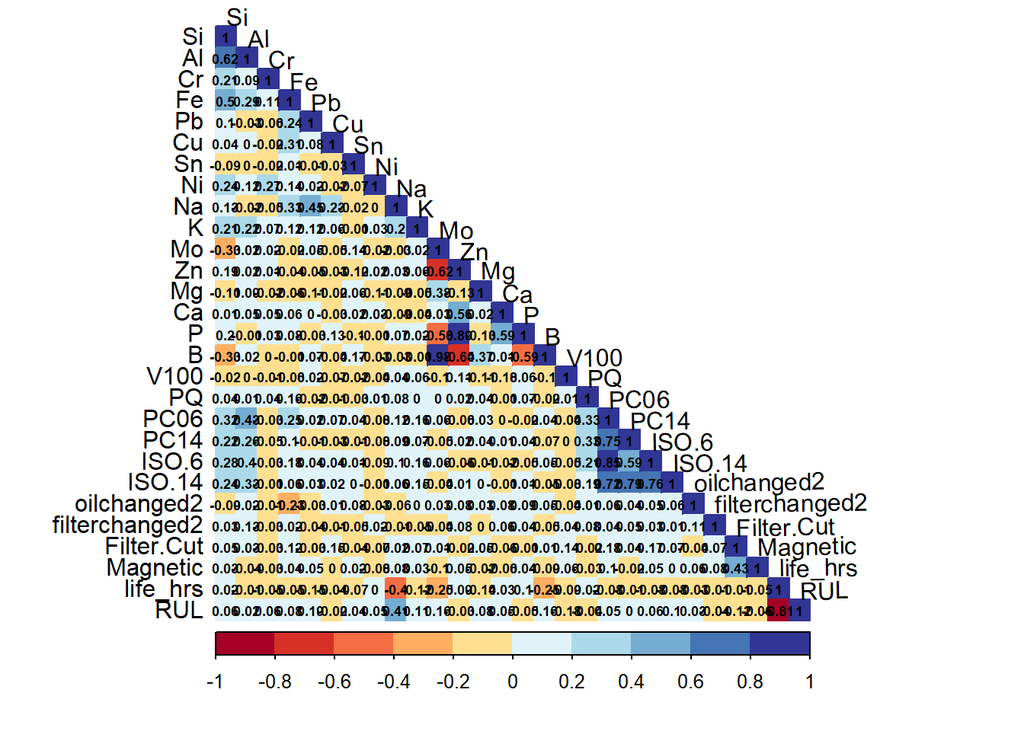

```r
df_fix %>%
  select(-c(unitno)) %>%
  mutate(
    oilchanged2 = as.numeric(oilchanged2),
    filterchanged2 = as.numeric(filterchanged2),
    Filter.Cut = as.numeric(Filter.Cut),
    Magnetic = as.numeric(Magnetic),
  ) %>%
  cor() %>%
  corrplot(method = "color",
           type = "lower",
           tl.col = "black", tl.srt = 1,
           addCoef.col = "black",
           number.cex = 0.55,
           col=brewer.pal(n = 10, name="RdYlBu"),
           mar=c(.25,0,.25,.25))
```

when we drop the missing data, we can normalized the data before processing into PCA. Normalization or Scaling data in R can be using with *scale* function that built in R which is Z-score normalization.

```r
  df_fix %>%
  select(-c(unitno, oilchanged2:RUL)) %>%
  as_tibble() %>%
  scale(center = TRUE, scale = TRUE)
```

```
##                Si         Al         Cr          Fe         Pb           Cu
##   [1,] -1.0707490  0.2021493 -0.1066016 -0.55226263 -0.5702156 -0.173700088
##   [2,] -0.8087808 -0.4748602 -0.1066016 -0.55226263 -0.5702156 -0.173700088
##   [3,] -1.3327173 -1.1518697 -0.1066016 -1.06549098  1.0491966 -0.173700088
##   [4,] -0.2848443  0.2021493 -0.1066016 -0.80887680 -0.5702156 -0.162607530
##   [5,] -0.8087808 -0.4748602 -0.1066016 -0.80887680  1.0491966 -0.118237297
##   [6,] -0.8087808 -0.4748602 -0.1066016 -0.55226263 -0.5702156 -0.018404273
##   [7,] -0.8087808 -1.1518697 -0.1066016 -1.06549098 -0.5702156 -0.096052181
##   [8,] -0.0228761 -1.1518697 -0.1066016 -0.80887680 -0.5702156  0.037058519
##   [9,] -0.2848443 -1.1518697 -0.1066016 -0.55226263  1.0491966  0.081428752
##  [10,] -0.5468126 -0.4748602 -0.1066016  0.21757991 -0.5702156  0.469668291
##  [11,]  0.2390921 -0.4748602 -0.1066016  0.21757991 -0.5702156  1.578924117
##  [12,] -0.0228761 -0.4748602 -0.1066016  0.73080827  1.0491966  1.179592019
##  [13,] -0.2848443  0.2021493 -0.1066016  0.73080827  4.2880210  1.024296204
##  [14,] -0.8087808  0.2021493 -0.1066016 -0.29564845 -0.5702156  0.103613868
```

[output cut: 1427 more lines]

```r
norm_minmax <- function(x){
                           (x- min(x)) /(max(x)-min(x))
}

df_fix %>%
  select(-c(unitno, oilchanged2:RUL)) %>%
  as_tibble() %>%
  norm_minmax()
```

| Si | Al | Cr | Fe | Pb | Cu | Sn | Ni | Na | K | Mo | Zn | Mg | Ca | P | B | V100 | PQ | PC06 | PC14 | ISO.6 | ISO.14 |
| --- | --- | --- | --- | --- | --- | --- | --- | --- | --- | --- | --- | --- | --- | --- | --- | --- | --- | --- | --- | --- | --- |
| 4.517188e-05 | 4.517188e-05 | 0.000000e+00 | 9.034376e-05 | 0.000000e+00 | 3.011459e-05 | 0.000000e+00 | 0.000000e+00 | 3.011459e-05 | 0.000000e+00 | 1.370214e-03 | 0.01453029 | 4.216042e-04 | 0.06634243 | 0.01412374 | 2.860886e-03 | 0.0001633716 | 1.505729e-05 | 0.08709138 | 0.0012949272 | 0.0003011459 | 0.0002108021 |
| 6.022917e-05 | 3.011459e-05 | 0.000000e+00 | 9.034376e-05 | 0.000000e+00 | 3.011459e-05 | 0.000000e+00 | 0.000000e+00 | 6.022917e-05 | 1.505729e-05 | 1.219641e-03 | 0.01483143 | 6.324063e-04 | 0.05619382 | 0.01522292 | 2.921115e-03 | 0.0001605107 | 1.505729e-05 | 0.03919413 | 0.0015960731 | 0.0002860886 | 0.0002108021 |
| 3.011459e-05 | 1.505729e-05 | 0.000000e+00 | 6.022917e-05 | 1.505729e-05 | 3.011459e-05 | 0.000000e+00 | 0.000000e+00 | 1.505729e-05 | 0.000000e+00 | 1.159412e-03 | 0.01392800 | 1.084125e-03 | 0.05474832 | 0.01412374 | 2.604912e-03 | 0.0001665337 | 0.000000e+00 | 0.05258007 | 0.0042310993 | 0.0002860886 | 0.0002258594 |
| 9.034376e-05 | 4.517188e-05 | 0.000000e+00 | 7.528646e-05 | 0.000000e+00 | 4.517188e-05 | 0.000000e+00 | 0.000000e+00 | 0.000000e+00 | 0.000000e+00 | 1.054011e-03 | 0.01282881 | 2.409167e-04 | 0.05280593 | 0.01299444 | 2.424224e-03 | 0.0001642751 | 0.000000e+00 | 0.43738425 | 0.0709198500 | 0.0003312604 | 0.0002860886 |
| 6.022917e-05 | 3.011459e-05 | 0.000000e+00 | 7.528646e-05 | 1.505729e-05 | 1.054011e-04 | 0.000000e+00 | 1.505729e-05 | 0.000000e+00 | 0.000000e+00 | 7.829792e-04 | 0.01442489 | 2.559740e-04 | 0.05446223 | 0.01486155 | 1.776761e-03 | 0.0001594567 | 1.505729e-05 | 0.12368060 | 0.0143345429 | 0.0003011459 | 0.0002559740 |
| 6.022917e-05 | 3.011459e-05 | 0.000000e+00 | 9.034376e-05 | 0.000000e+00 | 2.409167e-04 | 0.000000e+00 | 1.505729e-05 | 0.000000e+00 | 0.000000e+00 | 7.227501e-04 | 0.01451523 | 2.108021e-04 | 0.05113457 | 0.01346122 | 1.505729e-03 | 0.0001653291 | 1.505729e-04 | 0.20115038 | 0.0218631894 | 0.0003162032 | 0.0002710313 |
| 6.022917e-05 | 1.505729e-05 | 0.000000e+00 | 6.022917e-05 | 0.000000e+00 | 1.355156e-04 | 0.000000e+00 | 0.000000e+00 | 0.000000e+00 | 0.000000e+00 | 7.378074e-04 | 0.01331065 | 2.860886e-04 | 0.04402752 | 0.01338593 | 1.565958e-03 | 0.0001626188 | 3.011459e-05 | 0.16867180 | 0.0197852830 | 0.0003162032 | 0.0002710313 |
| 1.054011e-04 | 1.505729e-05 | 0.000000e+00 | 7.528646e-05 | 0.000000e+00 | 3.162032e-04 | 0.000000e+00 | 0.000000e+00 | 0.000000e+00 | 0.000000e+00 | 0.000000e+00 | 0.01510246 | 1.957448e-04 | 0.05513981 | 0.01537350 | 0.000000e+00 | 0.0001609625 | 1.505729e-05 | 0.16767801 | 0.0243777574 | 0.0003162032 | 0.0002710313 |
| 9.034376e-05 | 1.505729e-05 | 0.000000e+00 | 9.034376e-05 | 1.505729e-05 | 3.764323e-04 | 0.000000e+00 | 1.505729e-05 | 0.000000e+00 | 0.000000e+00 | 1.505729e-05 | 0.01693945 | 2.108021e-04 | 0.05983768 | 0.01587039 | 0.000000e+00 | 0.0001638233 | 0.000000e+00 | 0.11845572 | 0.0133407616 | 0.0003011459 | 0.0002559740 |
| 7.528646e-05 | 3.011459e-05 | 0.000000e+00 | 1.355156e-04 | 0.000000e+00 | 9.034376e-04 | 0.000000e+00 | 0.000000e+00 | 4.517188e-05 | 0.000000e+00 | 3.011459e-05 | 0.01499706 | 1.656302e-04 | 0.05912999 | 0.01564453 | 0.000000e+00 | 0.0001653291 | 1.656302e-04 | 0.25455860 | 0.0317558309 | 0.0003162032 | 0.0002710313 |

[output cut: 345 more lines]

PCA analysis with *prcomp()* package in R

```r
df_fix %>%
  select(-c(unitno, life_hrs:RUL)) %>%
  mutate(
    oilchanged2 = as.numeric(oilchanged2),
    filterchanged2 = as.numeric(filterchanged2),
    Filter.Cut = as.numeric(Filter.Cut),
    Magnetic = as.numeric(Magnetic),
  ) %>%
  prcomp(scale. = TRUE, center = TRUE) -> pca_trans

pca_trans
```

```
## Standard deviations (1, .., p=26):
##  [1] 1.9973286 1.8753587 1.4342214 1.3242746 1.2556339 1.1990745 1.0728866
##  [8] 1.0504121 1.0218057 1.0118067 0.9842449 0.9721182 0.9139585 0.8807742
## [15] 0.8313477 0.8253174 0.7125080 0.6846413 0.6336909 0.5825689 0.4700296
## [22] 0.4484751 0.3710597 0.2973265 0.2542943 0.1379861
##
## Rotation (n x k) = (26 x 26):
##                         PC1           PC2          PC3          PC4
## Si              0.310833249 -0.1014462134  0.278658389 -0.231605543
## Al              0.282434037  0.0813529199  0.088870714 -0.296158218
## Cr              0.029097930 -0.0288233848  0.141546593 -0.338798761
## Fe              0.206866660  0.0154238418  0.439210902 -0.111147694
## Pb              0.048741699  0.0293823572  0.347957153  0.127588734
## Cu              0.066037079 -0.0182620742  0.241136859  0.113631604
## Sn             -0.037236853  0.1027829528 -0.052783234 -0.016568132
## Ni              0.020413886 -0.0496711790  0.221523772 -0.352486686
## Na              0.118471399 -0.0001836218  0.369835581  0.209925815
## K               0.138441939  0.0247677084  0.199832032 -0.002961147
## Mo             -0.143497710  0.4349915354  0.006710617 -0.173910429
## Zn              0.129794572 -0.4461161397 -0.156942876 -0.068286054
## Mg             -0.053408335  0.1937144181 -0.137417345 -0.147486474
## Ca              0.049852550 -0.1897118549 -0.180674721 -0.339043217
## P               0.143255099 -0.4306519101 -0.117744223 -0.073637892
## B              -0.152941521  0.4365324841  0.014918255 -0.160874027
## V100           -0.004491263 -0.0678047614  0.037889661  0.258449225
## PQ              0.162527535  0.0530297124 -0.089219766  0.008301362
## PC06            0.417712548  0.2005494188 -0.121743199  0.063196266
## PC14            0.371896317  0.1324348765 -0.230370382  0.060102121
## ISO.6           0.388907871  0.1955820910 -0.127366161  0.064635668
## ISO.14          0.385460075  0.1499452472 -0.202890140  0.036505586
## oilchanged2     0.009029951 -0.0018374937 -0.236271266 -0.009680230
## filterchanged2  0.049650237 -0.0323155037 -0.067849393  0.003705408
## Filter.Cut      0.086266916  0.0388014379  0.073574211  0.335321729
## Magnetic        0.049990344 -0.0307763685  0.053984410  0.371857381
##                         PC5          PC6          PC7          PC8
## Si              0.189689306 -0.144431632  0.055364395  0.119717701
## Al              0.131114952 -0.246701368  0.174420703  0.148124094
## Cr              0.161503098 -0.158560505 -0.014501719 -0.256313761
## Fe             -0.161954799 -0.044007433 -0.274476343  0.047521343
## Pb             -0.279146778  0.260460808  0.268669846 -0.163300234
```

[output cut: 114 more lines]

```
## Zn             -0.322208632  0.738483429 -5.408371e-02  0.028764726
## Mg              0.151533496 -0.038679377  2.234480e-02  0.004687755
## Ca              0.606754648 -0.042689475  6.557821e-02  0.009676066
## P              -0.486849788 -0.646920754 -3.797623e-02 -0.020956780
## B              -0.283424683  0.031435715 -9.031556e-02  0.704565848
## V100            0.149891614 -0.028474505  3.529737e-02 -0.001213452
## PQ              0.071039092  0.013675336 -9.331557e-03  0.002887620
## PC06           -0.152822919  0.033757792  5.754166e-01  0.060516979
## PC14           -0.062481557  0.025683863 -4.583780e-01 -0.016701468
## ISO.6           0.130773184 -0.036335206 -5.236923e-01 -0.036299264
## ISO.14          0.048262849 -0.007348775  3.908279e-01  0.013199187
## oilchanged2     0.056664250  0.018855707  3.192920e-03 -0.020425026
## filterchanged2 -0.032322896 -0.033521212  1.891202e-02  0.011376708
## Filter.Cut     -0.006998614 -0.001777536  1.189099e-02 -0.006979717
## Magnetic        0.010633405 -0.007020229 -6.233443e-02 -0.008436682
```

Create a screeplot to find how much *n*

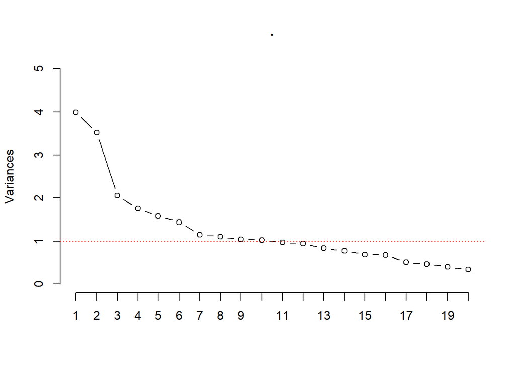

```
## integer(0)
```

```r
pca_trans %>%
  screeplot(type = "line", npcs = 20, ylim = c(0,5)) +
  abline(h = 1, lty = 3, col = "red") # based on scree plot pca n = 6
```

```r
summary(pca_trans)
```

```
## Importance of components:
##                           PC1    PC2     PC3     PC4     PC5    PC6     PC7
## Standard deviation     1.9973 1.8754 1.43422 1.32427 1.25563 1.1991 1.07289
## Proportion of Variance 0.1534 0.1353 0.07912 0.06745 0.06064 0.0553 0.04427
## Cumulative Proportion  0.1534 0.2887 0.36782 0.43527 0.49591 0.5512 0.59548
##                            PC8     PC9    PC10    PC11    PC12    PC13    PC14
## Standard deviation     1.05041 1.02181 1.01181 0.98424 0.97212 0.91396 0.88077
## Proportion of Variance 0.04244 0.04016 0.03938 0.03726 0.03635 0.03213 0.02984
## Cumulative Proportion  0.63792 0.67807 0.71745 0.75471 0.79105 0.82318 0.85302
##                           PC15   PC16    PC17    PC18    PC19    PC20   PC21
## Standard deviation     0.83135 0.8253 0.71251 0.68464 0.63369 0.58257 0.4700
## Proportion of Variance 0.02658 0.0262 0.01953 0.01803 0.01544 0.01305 0.0085
## Cumulative Proportion  0.87960 0.9058 0.92533 0.94335 0.95880 0.97185 0.9804
##                           PC22   PC23   PC24    PC25    PC26
## Standard deviation     0.44848 0.3711 0.2973 0.25429 0.13799
## Proportion of Variance 0.00774 0.0053 0.0034 0.00249 0.00073
## Cumulative Proportion  0.98808 0.9934 0.9968 0.99927 1.00000
```

Plotting of Individual PC is representative percentage for variables in dataset.

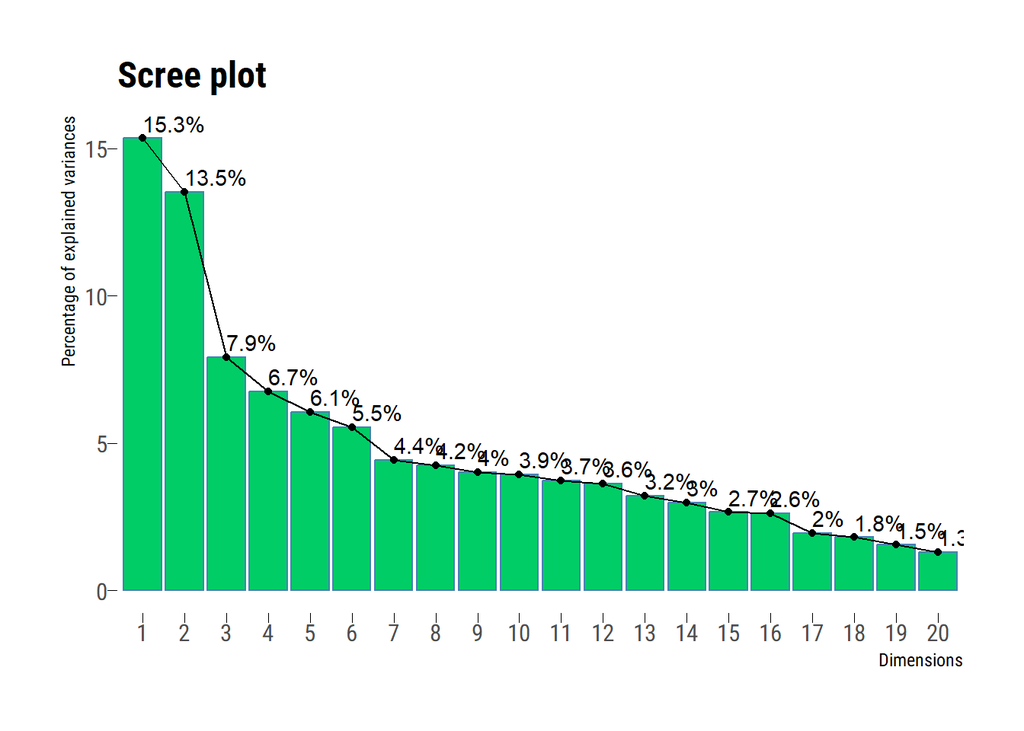

```r
pca_trans %>%
  fviz_eig(addlabels = TRUE, ncp = 20,
           barfill = "springgreen3",
           ggtheme = theme_ipsum_rc(
             ticks = TRUE,
             grid = FALSE
           ))
```

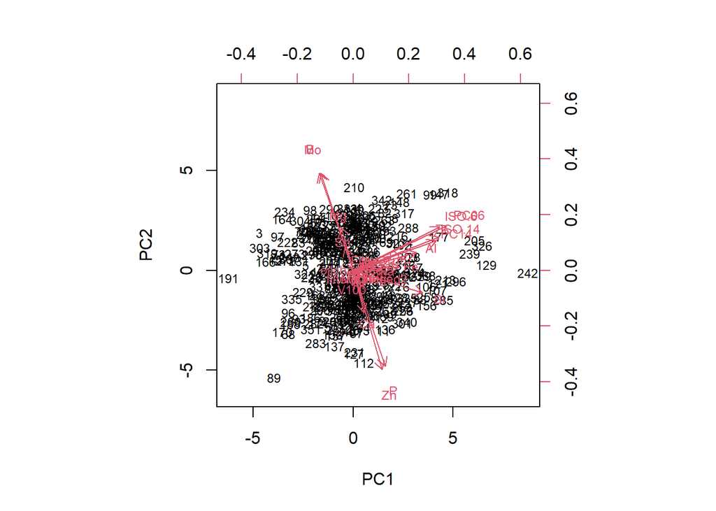

```r
pca_trans %>%
  biplot(scale = 0, cex = .75)
```

Another thing you can do to easily see the grouping of different variables is a biplot. With this plot could be found that It’s important to know what your components are made up of. In other words, which variables contribute to any given component.

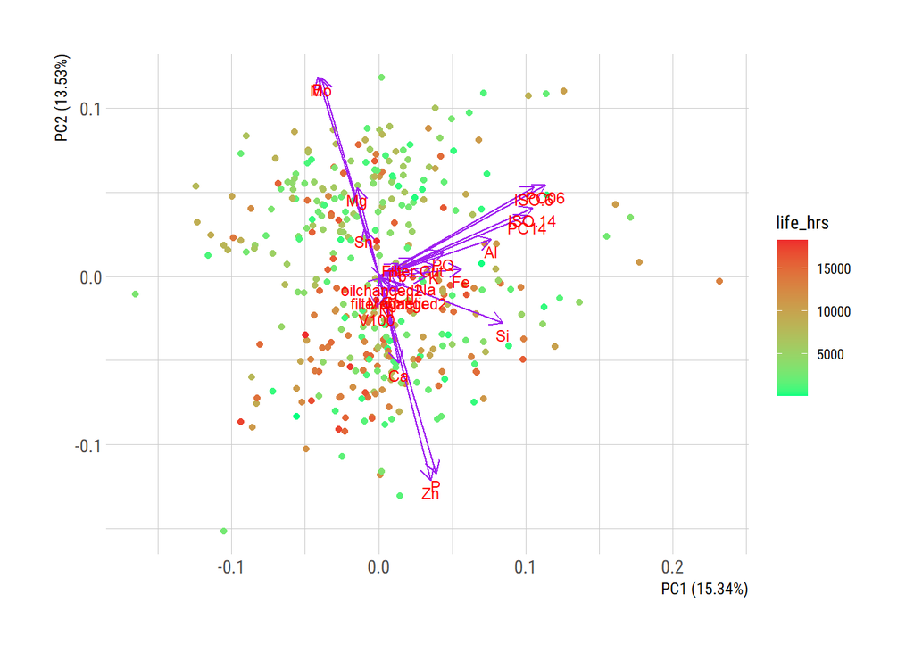

```r
pca_trans %>%
  autoplot(data = df_fix, colour = 'life_hrs',
           loadings = TRUE, loadings.label = TRUE, loadings.colour = "purple", loadings.label.size = 3, scale = 1,
           loadings.label.vjust = 1.5) +
  scale_color_gradient(low="springgreen", high="firebrick2") +
  theme_ipsum_rc(
    base_size = 10,
    plot_title_size = 12,
    subtitle_size = 10,
    strip_text_face = "bold",
    grid = TRUE,
    ticks = FALSE
  )
```

```r
print(pca_trans$rotation)
```

```
##                         PC1           PC2          PC3          PC4
## Si              0.310833249 -0.1014462134  0.278658389 -0.231605543
## Al              0.282434037  0.0813529199  0.088870714 -0.296158218
## Cr              0.029097930 -0.0288233848  0.141546593 -0.338798761
## Fe              0.206866660  0.0154238418  0.439210902 -0.111147694
## Pb              0.048741699  0.0293823572  0.347957153  0.127588734
## Cu              0.066037079 -0.0182620742  0.241136859  0.113631604
## Sn             -0.037236853  0.1027829528 -0.052783234 -0.016568132
## Ni              0.020413886 -0.0496711790  0.221523772 -0.352486686
## Na              0.118471399 -0.0001836218  0.369835581  0.209925815
## K               0.138441939  0.0247677084  0.199832032 -0.002961147
## Mo             -0.143497710  0.4349915354  0.006710617 -0.173910429
## Zn              0.129794572 -0.4461161397 -0.156942876 -0.068286054
## Mg             -0.053408335  0.1937144181 -0.137417345 -0.147486474
## Ca              0.049852550 -0.1897118549 -0.180674721 -0.339043217
## P               0.143255099 -0.4306519101 -0.117744223 -0.073637892
## B              -0.152941521  0.4365324841  0.014918255 -0.160874027
## V100           -0.004491263 -0.0678047614  0.037889661  0.258449225
## PQ              0.162527535  0.0530297124 -0.089219766  0.008301362
## PC06            0.417712548  0.2005494188 -0.121743199  0.063196266
## PC14            0.371896317  0.1324348765 -0.230370382  0.060102121
## ISO.6           0.388907871  0.1955820910 -0.127366161  0.064635668
## ISO.14          0.385460075  0.1499452472 -0.202890140  0.036505586
## oilchanged2     0.009029951 -0.0018374937 -0.236271266 -0.009680230
## filterchanged2  0.049650237 -0.0323155037 -0.067849393  0.003705408
## Filter.Cut      0.086266916  0.0388014379  0.073574211  0.335321729
## Magnetic        0.049990344 -0.0307763685  0.053984410  0.371857381
##                         PC5          PC6          PC7          PC8
## Si              0.189689306 -0.144431632  0.055364395  0.119717701
## Al              0.131114952 -0.246701368  0.174420703  0.148124094
## Cr              0.161503098 -0.158560505 -0.014501719 -0.256313761
## Fe             -0.161954799 -0.044007433 -0.274476343  0.047521343
## Pb             -0.279146778  0.260460808  0.268669846 -0.163300234
## Cu             -0.261970508 -0.002379934 -0.287672327  0.174607071
## Sn             -0.133794010 -0.015679433  0.272811876  0.131513768
## Ni              0.205345034 -0.044220175  0.002553501 -0.311091320
## Na             -0.290325897  0.251735037  0.103473148 -0.171156487
## K              -0.025408654 -0.052554887  0.456851994  0.064335480
## Mo             -0.242029847 -0.083698091  0.030852987 -0.085103012
## Zn             -0.194569446 -0.048040937  0.075512997 -0.002930565
```

[output cut: 107 more lines]

```
## Zn             -0.322208632  0.738483429 -5.408371e-02  0.028764726
## Mg              0.151533496 -0.038679377  2.234480e-02  0.004687755
## Ca              0.606754648 -0.042689475  6.557821e-02  0.009676066
## P              -0.486849788 -0.646920754 -3.797623e-02 -0.020956780
## B              -0.283424683  0.031435715 -9.031556e-02  0.704565848
## V100            0.149891614 -0.028474505  3.529737e-02 -0.001213452
## PQ              0.071039092  0.013675336 -9.331557e-03  0.002887620
## PC06           -0.152822919  0.033757792  5.754166e-01  0.060516979
## PC14           -0.062481557  0.025683863 -4.583780e-01 -0.016701468
## ISO.6           0.130773184 -0.036335206 -5.236923e-01 -0.036299264
## ISO.14          0.048262849 -0.007348775  3.908279e-01  0.013199187
## oilchanged2     0.056664250  0.018855707  3.192920e-03 -0.020425026
## filterchanged2 -0.032322896 -0.033521212  1.891202e-02  0.011376708
## Filter.Cut     -0.006998614 -0.001777536  1.189099e-02 -0.006979717
## Magnetic        0.010633405 -0.007020229 -6.233443e-02 -0.008436682
```

If we want to analysis top-12 PC in dataset.

```r
print(pca_trans$rotation[,1:12])
```

```
##                         PC1           PC2          PC3          PC4
## Si              0.310833249 -0.1014462134  0.278658389 -0.231605543
## Al              0.282434037  0.0813529199  0.088870714 -0.296158218
## Cr              0.029097930 -0.0288233848  0.141546593 -0.338798761
## Fe              0.206866660  0.0154238418  0.439210902 -0.111147694
## Pb              0.048741699  0.0293823572  0.347957153  0.127588734
## Cu              0.066037079 -0.0182620742  0.241136859  0.113631604
## Sn             -0.037236853  0.1027829528 -0.052783234 -0.016568132
## Ni              0.020413886 -0.0496711790  0.221523772 -0.352486686
## Na              0.118471399 -0.0001836218  0.369835581  0.209925815
## K               0.138441939  0.0247677084  0.199832032 -0.002961147
## Mo             -0.143497710  0.4349915354  0.006710617 -0.173910429
## Zn              0.129794572 -0.4461161397 -0.156942876 -0.068286054
## Mg             -0.053408335  0.1937144181 -0.137417345 -0.147486474
## Ca              0.049852550 -0.1897118549 -0.180674721 -0.339043217
## P               0.143255099 -0.4306519101 -0.117744223 -0.073637892
## B              -0.152941521  0.4365324841  0.014918255 -0.160874027
## V100           -0.004491263 -0.0678047614  0.037889661  0.258449225
## PQ              0.162527535  0.0530297124 -0.089219766  0.008301362
## PC06            0.417712548  0.2005494188 -0.121743199  0.063196266
## PC14            0.371896317  0.1324348765 -0.230370382  0.060102121
## ISO.6           0.388907871  0.1955820910 -0.127366161  0.064635668
## ISO.14          0.385460075  0.1499452472 -0.202890140  0.036505586
## oilchanged2     0.009029951 -0.0018374937 -0.236271266 -0.009680230
## filterchanged2  0.049650237 -0.0323155037 -0.067849393  0.003705408
## Filter.Cut      0.086266916  0.0388014379  0.073574211  0.335321729
## Magnetic        0.049990344 -0.0307763685  0.053984410  0.371857381
##                         PC5          PC6          PC7          PC8
## Si              0.189689306 -0.144431632  0.055364395  0.119717701
## Al              0.131114952 -0.246701368  0.174420703  0.148124094
## Cr              0.161503098 -0.158560505 -0.014501719 -0.256313761
## Fe             -0.161954799 -0.044007433 -0.274476343  0.047521343
## Pb             -0.279146778  0.260460808  0.268669846 -0.163300234
## Cu             -0.261970508 -0.002379934 -0.287672327  0.174607071
## Sn             -0.133794010 -0.015679433  0.272811876  0.131513768
## Ni              0.205345034 -0.044220175  0.002553501 -0.311091320
## Na             -0.290325897  0.251735037  0.103473148 -0.171156487
## K              -0.025408654 -0.052554887  0.456851994  0.064335480
## Mo             -0.242029847 -0.083698091  0.030852987 -0.085103012
## Zn             -0.194569446 -0.048040937  0.075512997 -0.002930565
```

[output cut: 26 more lines]

```
## Zn              0.1628302501 -0.016121226  0.0180322066  0.010091685
## Mg              0.2168672583 -0.171371645  0.0496034297  0.183895319
## Ca              0.1428893736  0.048649233 -0.0006336854 -0.207353187
## P               0.1009205441  0.047658338 -0.0002039228  0.082175543
## B               0.1144994517  0.002458441  0.0468251902 -0.021698041
## V100            0.4901522285 -0.153065363 -0.1695980394  0.346993048
## PQ              0.1982779331  0.101736145 -0.1931827919  0.208095039
## PC06           -0.0005516509  0.055045863 -0.0309061453 -0.015496942
## PC14            0.0576309394  0.043897825 -0.0014636870 -0.029003377
## ISO.6          -0.0313716024  0.050882662  0.0594044407 -0.071676860
## ISO.14         -0.0471974187  0.118015136  0.1139262437 -0.072162198
## oilchanged2    -0.4656492668  0.093072971  0.1411323062  0.261458802
## filterchanged2 -0.2857471135 -0.552070557 -0.0614977219 -0.048335534
## Filter.Cut      0.0885500391  0.181164163  0.0997811591 -0.046901775
## Magnetic       -0.0542536673  0.234924557 -0.0712575976 -0.318637968
```

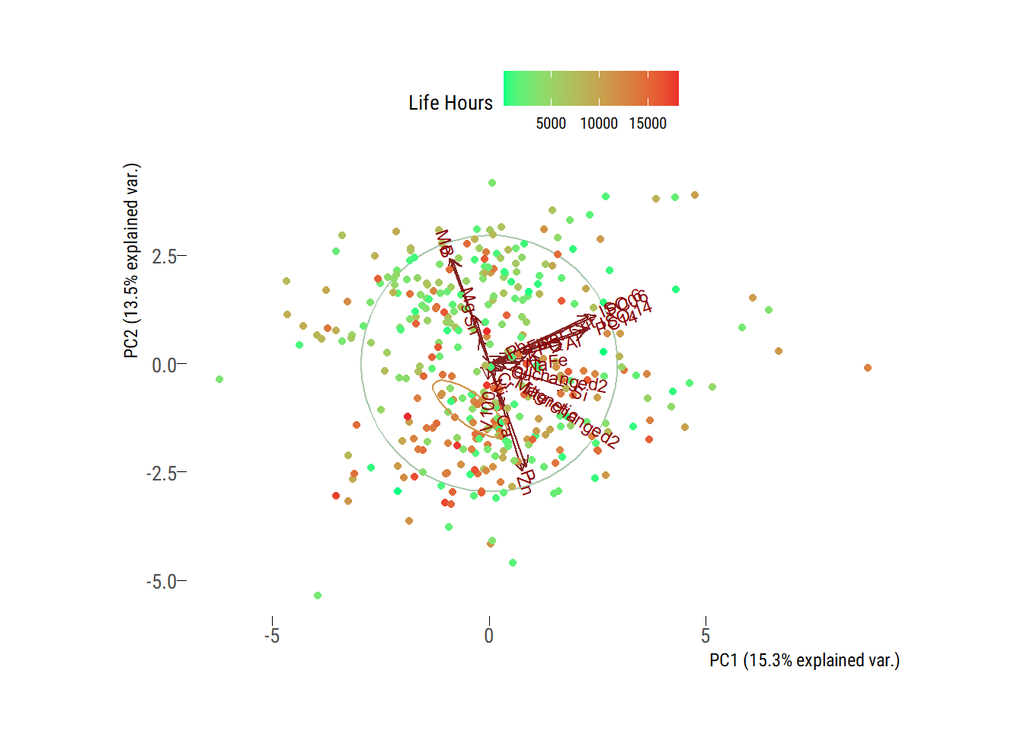

```r
pca_trans %>%
  ggbiplot(
    obs.scale = 1,
    var.scale = 1,
    groups = df_fix$life_hrs,
    ellipse = TRUE,
    circle = TRUE,
    ellipse.prob = 0.68
  ) +
  # scale_color_discrete(name = '') +
  scale_color_gradient(low="springgreen", high="firebrick2", name = "Life Hours") +
  theme_ipsum_rc(
    base_size = 10,
    plot_title_size = 12,
    subtitle_size = 10,
    strip_text_face = "bold",
    grid = FALSE,
    ticks = TRUE
  ) +
  theme(
    legend.direction = 'horizontal',
    legend.position = 'top'
  )
```